# One- vs. Two-Step Approach in Regularized Bayesian SEM

22-09-2021

## Bayesian SEM

- Recap normal SEM (CFA):
  - Identification constraints
  - Cross-loadings fixed to zero: \(\mathcal{N}(0, 0)\)
  - If bad fit: Adjust model based on modification indices (flawed)
- Bayesian context (Muthen and Asparouhov 2012)
  - Don’t just assume that cross-loadings are zero
  - Instead make a more realistic and flexible assumption:
    - Small Variance Prior: \(\mathcal{N}(0, 0.01)\)
    - allowing for a more continuous model selection (between EFA & CFA)

## Small variance prior

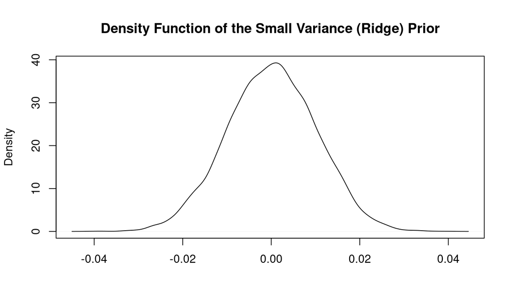

\[\mathcal{N}(\mu = 0, \sigma = 0.01)\]

## Regularization

- Frequentist context: Penatalization, such as LASSO (Tibshirani 1996) or ridge (Hoerl and Kennard 2000)

\[argmin\{ (\bf{Y} - \bf{X} \bf{\beta})^2 + \Sigma_{j = 1}^{p} |\beta_{j}^q|\} \]

- In Bayesian context: Use *shrinkage priors* to achieve the same (Erp, Oberski, and Mulder 2019), e.g. Bayesian lasso, (Park and Casella 2008)
- *Regularized (Bayesian) SEM* (Jacobucci, Grimm, and McArdle 2016):
  - Bayesian SEM by Muthen and Asparouhov (2012) is simply a form of regularization, where cross-loadings are reguralized
  - small variance prior is literally the same as applying the ridge penality to the cross-loadings (Hsiang 1975)

## Research Gap & Aim

- Original approach with the small variance prior requires a 2-step approach (Lu, Chow, and Loken 2016)
  - Not only the parameters close to zero are shrunken to zero (as desired)…
  - But also the parameters that are far from zero, and should not be shrunken (introducing bias!)
  - Intermediate solution: fit regularized model in first step and in second step fit unreguralized models where those loadings that were shrunken to zero in previous step are fixed to zero.
    - Comes with many disadvantages
- Therefore, more advanced priors need to be identified that can outperform the small-variance prior in a single step

## Methods

- Monte Carlo Simulation
- Outcomes:
  - True Positives vs. False Positives (e.g. ROC, )
  - 95% coverage?
- Conditions:
  - N, *N > p* vs. *p < N*
- Stan (Carpenter et al. 2017)
  - Hamilton Monte Carlo (Betancourt 2018)
- Check out my [Github Repository](https://github.com/JMBKoch/1vs2StepBayesianRegularizedSEM)

## References

Betancourt, Michael. 2018. “A Conceptual Introduction to Hamiltonian Monte Carlo.” *arXiv:1701.02434 [Stat]*, July. http://arxiv.org/abs/1701.02434.

Carpenter, Bob, Andrew Gelman, Matthew D. Hoffman, Daniel Lee, Ben Goodrich, Michael Betancourt, Marcus Brubaker, Jiqiang Guo, Peter Li, and Allen Riddell. 2017. “Stan: A Probabilistic Programming Language.” *Journal of Statistical Software* 76 (1): 1–32. https://doi.org/10.18637/jss.v076.i01.

Carvalho, Carlos M., Nicholas G. Polson, and James G. Scott. 2010. “The Horseshoe Estimator for Sparse Signals.” *Biometrika* 97 (2): 465–80. https://www.jstor.org/stable/25734098.

Erp, Sara van, Daniel L. Oberski, and Joris Mulder. 2019. “Shrinkage Priors for Bayesian Penalized Regression.” *Journal of Mathematical Psychology* 89 (April): 31–50. https://doi.org/10.1016/j.jmp.2018.12.004.

Hoerl, Arthur E., and Robert W. Kennard. 2000. “Ridge Regression: Biased Estimation for Nonorthogonal Problems.” *Technometrics* 42 (1): 80–86. https://doi.org/10.2307/1271436.

Hsiang, T. C. 1975. “A Bayesian View on Ridge Regression.” *Journal of the Royal Statistical Society. Series D (The Statistician)* 24 (4): 267–68. https://doi.org/10.2307/2987923.

Jacobucci, Ross, Kevin J. Grimm, and John J. McArdle. 2016. “Regularized Structural Equation Modeling.” *Structural Equation Modeling: A Multidisciplinary Journal* 23 (4): 555–66. https://doi.org/10.1080/10705511.2016.1154793.

Lu, Zhao-Hua, Sy-Miin Chow, and Eric Loken. 2016. “Bayesian Factor Analysis as a Variable- Selection Problem: Alternative Priors and Consequences.” *Multivariate Behavioral Research* 51 (4): 519–39. https://doi.org/10.1080/00273171.2016.1168279.

Muthen, Bengt, and Tihomir Asparouhov. 2012. “Bayesian SEM: A More FLexible Representation of Substantive Theory,” 78. https://doi.org/10.1037/a0026802.

Park, Trevor, and George Casella. 2008. “The Bayesian Lasso.” *Journal of the American Statistical Association* 103 (482): 681–86. https://doi.org/10.1198/016214508000000337.

Piironen, Juho, and Aki Vehtari. 2017. “Sparsity Information and Regularization in the Horseshoe and Other Shrinkage Priors.” *Electronic Journal of Statistics* 11 (2): 5018–51. https://doi.org/10.1214/17-EJS1337SI.

Tibshirani, Robert. 1996. “Regression Shrinkage and Selection Via the Lasso.” *Journal of the Royal Statistical Society: Series B (Methodological)* 58 (1): 267–88. https://doi.org/10.1111/j.2517-6161.1996.tb02080.x.